# Attention questions for Sally

May Dixon

# Major questions:

Thank you so much for your help, you all are saviors. I have 9 questions (all labelled) for you about the tests that I am running. This got sort of long, so if you feel like you can only help with a few of these, that would still be wonderful.

## Habituation

This is the main work for which I originally sought help. To reorient you, I am studying how bats habituate to different frog calls. I measure habituation as a decrease in response (ear twitches/ all_tw_call) over time. I am currently testing to see whether the treatments (contained in trial_name_2) interact with call number (call_num, my time proxy) to explain the number of twitches. I have bat ID and trial number (which refers to when in the testing the bat got a given treatment) as random effects. My model looks like:

`twitches/call ~ call number*treatment , random = batID, trial number`

I have a few questions about my methods!

So, first, I’m just going to show you my data and the tests I have run. (All the raw data can be found at: https://github.com/maydixon/Attn_Project [link](https://github.com/maydixon/Attn_Project) ) :

##### Summary stats:

```
## 'data.frame':    2970 obs. of  40 variables:
##  $ Bat_ID         : Factor w/ 11 levels "Bat10","Bat11",..: 1 1 1 1 1 1 1 1 1 1 ...
##  $ bat_name       : Factor w/ 11 levels "Boba_Bat","Captain_Henry_Morgan",..: 6 6 6 6 6 6 6 6 6 6 ...
##  $ video_ID       : Factor w/ 110 levels "M2U02180","M2U02181",..: 27 27 27 27 27 27 27 27 27 27 ...
##  $ trial_name     : Factor w/ 18 levels "de_t_de","ra_t_ra",..: 1 1 1 1 1 1 1 1 1 1 ...
##  $ trial_name_2   : Factor w/ 9 levels "de_t_de","ra_t_ra",..: 1 1 1 1 1 1 1 1 1 1 ...
##  $ primary_stim   : Factor w/ 7 levels "de","ra","rra",..: 1 1 1 1 1 1 1 1 1 1 ...
##  $ trial_number   : int  6 6 6 6 6 6 6 6 6 6 ...
##  $ sm_tw_trial    : int  3 3 3 3 3 3 3 3 3 3 ...
##  $ md_tw_trial    : int  1 1 1 1 1 1 1 1 1 1 ...
##  $ lg_tw_trial    : int  0 0 0 0 0 0 0 0 0 0 ...
##  $ Orienting_trial: int  0 0 0 0 0 0 0 0 0 0 ...
##  $ Flying_trial   : int  0 0 0 0 0 0 0 0 0 0 ...
##  $ Approach_trial : int  0 0 0 0 0 0 0 0 0 0 ...
##  $ Grooming_trial : int  0 0 0 0 0 0 0 0 0 0 ...
```

[output cut: 26 more lines]

##### So now, running a linear mixed model using the lme function:

My FIRST THREE Questions regard how to call this:

##### 1.

I currently have trial number as a random effect (see below). But if anything, I expect there to be a negative relationship between number of twitches and trial number (bats get bored over time). Other than that I don’t really care about this variable. If I think it should have a trend, should I make it a fixed effect? How will this affect the power of my model?

##### 3.

I read that you should have random slopes as well as random intercepts, bc random intercept only models have a high type 1 error rate. When I tried this, my model didn’t converge. I may just be calling it wrong. Any advice? Could you show me how to call this right? The way I coded it below just makes my r freeze:

`nlme_int3 <- lme(all_tw_call ~ call_num*trial_name_2, random = list(Bat_ID=+1 , trial_number= +1), data= attn_habit_3)`

Anyway, here is how I have been running it:

```r
nlme_int3 <- lme(all_tw_call ~ call_num*trial_name_2, random = list(Bat_ID=~1 , trial_number= ~1), data= attn_habit_3) # does glm
        sum_lme3<- summary(nlme_int3) #summary
        sum_lme3
```

```
## Linear mixed-effects model fit by REML
##  Data: attn_habit_3
##        AIC      BIC    logLik
##   7023.869 7149.664 -3490.935
##
## Random effects:
##  Formula: ~1 | Bat_ID
##         (Intercept)
## StdDev:   0.3322299
##
##  Formula: ~1 | trial_number %in% Bat_ID
##         (Intercept)  Residual
## StdDev:   0.4099717 0.7436932
##
## Fixed effects: all_tw_call ~ call_num * trial_name_2
##                                       Value  Std.Error   DF   t-value
## (Intercept)                       0.8769577 0.19536555 2849  4.488804
## call_num                          0.0361836 0.03155381 2849  1.146727
## trial_name_2ra_t_ra               0.3676310 0.23019622   93  1.597033
## trial_name_2rra_rt_rra            0.8944709 0.23019622   93  3.885689
## trial_name_2rt_rra_rt             0.4017282 0.23720647   93  1.693580
## trial_name_2t_de_t                0.1348875 0.23720647   93  0.568650
## trial_name_2t_ra_t                0.1456526 0.23720647   93  0.614033
## trial_name_2tc_ts_tc              0.3989786 0.24083194 2849  1.656668
## trial_name_2tia_tib_tia           0.2314941 0.20542683   93  1.126893
## trial_name_2ts_tc_ts              0.2859097 0.23201952 2849  1.232266
## call_num:trial_name_2ra_t_ra     -0.2899397 0.04122917 2849 -7.032392
## call_num:trial_name_2rra_rt_rra  -0.3807214 0.04122917 2849 -9.234274
## call_num:trial_name_2rt_rra_rt   -0.1922592 0.04462383 2849 -4.308443
## call_num:trial_name_2t_de_t      -0.0948695 0.04462383 2849 -2.125983
## call_num:trial_name_2t_ra_t      -0.1333933 0.04462383 2849 -2.989285
## call_num:trial_name_2tc_ts_tc    -0.0859650 0.04562184 2849 -1.884295
## call_num:trial_name_2tia_tib_tia -0.1412241 0.03864537 2849 -3.654361
## call_num:trial_name_2ts_tc_ts    -0.1775861 0.04377137 2849 -4.057130
##                                  p-value
## (Intercept)                       0.0000
## call_num                          0.2516
## trial_name_2ra_t_ra               0.1137
## trial_name_2rra_rt_rra            0.0002
## trial_name_2rt_rra_rt             0.0937
```

[output cut: 134 more lines]

```
## call_num:trial_name_2rt_rra_rt
## call_num:trial_name_2t_de_t
## call_num:trial_name_2t_ra_t
## call_num:trial_name_2tc_ts_tc
## call_num:trial_name_2tia_tib_tia
## call_num:trial_name_2ts_tc_ts     0.589
##
## Standardized Within-Group Residuals:
##        Min         Q1        Med         Q3        Max
## -2.5709047 -0.5789884 -0.1058623  0.4915617 11.2146222
##
## Number of Observations: 2970
## Number of Groups:
##                   Bat_ID trial_number %in% Bat_ID
##                       11                      110
```

So, if I understand this correctly: - The random variables Bat ID and trial number explain 0.33 (0.33%?) and .41 of the variation. 0.74 is the amount of variation (the majority, I guess behavior is just messy?) unexplained by this model.

- Call number is the slope to which I compare everything else (the relationship between call number and # twitches), and it is 0.036
- The P-values describe whether the given treatment or interactions describe a significant amount of the variation.

##### 4.

What should my significance level/alpha value be in this situation? Do these count as multiple comparisons? What are guidelines to use for this decision?

##### 5.

One thing that I am potentially interested in is the initial interest that the bats had in each of the treatments. Thus, the comparative response that they had to each treatment at time 0. Is this what my intercept is? For example, if my reference is “de”, then is the Intercept = 0.88 the response to de at time 0? If there is a significant p-value, can I interpret intercepts thus?

##### 6.

If this isn’t how the interecpt works, what does the intercept mean in this context?

#### 7.

I realize I pretty much don’t care about the main effects of call number alone or of treatment alone on twitch number. Could I reduce the complexity of my model by only including the interaction effects (thus):

```r
nlme_int6 <- lme(all_tw_call ~ call_num:trial_name_2, random = list(Bat_ID=~1 , trial_number= ~1), data= attn_habit_3) #only interaction, not main effects
summary(nlme_int6)
```

```
## Linear mixed-effects model fit by REML
##  Data: attn_habit_3
##        AIC      BIC    logLik
##   7015.341 7093.249 -3494.671
##
## Random effects:
##  Formula: ~1 | Bat_ID
##         (Intercept)
## StdDev:   0.3305771
##
##  Formula: ~1 | trial_number %in% Bat_ID
##         (Intercept)  Residual
## StdDev:   0.4310501 0.7441225
##
## Fixed effects: all_tw_call ~ call_num:trial_name_2
##                                       Value  Std.Error   DF    t-value
## (Intercept)                       1.1931213 0.11330796 2851  10.529898
## call_num:trial_name_2de_t_de      0.0012375 0.02585898 2851   0.047854
## call_num:trial_name_2ra_t_ra     -0.2490970 0.02262344 2851 -11.010571
## call_num:trial_name_2rra_rt_rra  -0.2921867 0.02262344 2851 -12.915220
## call_num:trial_name_2rt_rra_rt   -0.1466180 0.02585898 2851  -5.669906
## call_num:trial_name_2t_de_t      -0.0787227 0.02585898 2851  -3.044306
## call_num:trial_name_2t_ra_t      -0.1160566 0.02585898 2851  -4.488059
## call_num:trial_name_2tc_ts_tc    -0.0404319 0.02707662 2851  -1.493240
## call_num:trial_name_2tia_tib_tia -0.1143992 0.01876388 2851  -6.096776
## call_num:trial_name_2ts_tc_ts    -0.1451010 0.02477536 2851  -5.856665
##                                  p-value
## (Intercept)                       0.0000
## call_num:trial_name_2de_t_de      0.9618
## call_num:trial_name_2ra_t_ra      0.0000
## call_num:trial_name_2rra_rt_rra   0.0000
## call_num:trial_name_2rt_rra_rt    0.0000
## call_num:trial_name_2t_de_t       0.0024
## call_num:trial_name_2t_ra_t       0.0000
## call_num:trial_name_2tc_ts_tc     0.1355
## call_num:trial_name_2tia_tib_tia  0.0000
## call_num:trial_name_2ts_tc_ts     0.0000
##  Correlation:
##                                  (Intr) cll_nm:trl_nm_2d__
## call_num:trial_name_2de_t_de     -0.110
```

[output cut: 42 more lines]

```
## call_num:trial_name_2rt_rra_rt
## call_num:trial_name_2t_de_t
## call_num:trial_name_2t_ra_t
## call_num:trial_name_2tc_ts_tc
## call_num:trial_name_2tia_tib_tia
## call_num:trial_name_2ts_tc_ts     0.076
##
## Standardized Within-Group Residuals:
##        Min         Q1        Med         Q3        Max
## -2.6005140 -0.5797038 -0.1142352  0.4947688 11.1871309
##
## Number of Observations: 2970
## Number of Groups:
##                   Bat_ID trial_number %in% Bat_ID
##                       11                      110
```

### Now, I want to compare whether the bats habituated to each treatment at a different rate

```r
 summary(nlme_int3)$tTable
```

```
##                                        Value  Std.Error   DF    t-value
## (Intercept)                       0.87695770 0.19536555 2849  4.4888041
## call_num                          0.03618362 0.03155381 2849  1.1467274
## trial_name_2ra_t_ra               0.36763105 0.23019622   93  1.5970334
## trial_name_2rra_rt_rra            0.89447088 0.23019622   93  3.8856889
## trial_name_2rt_rra_rt             0.40172817 0.23720647   93  1.6935801
## trial_name_2t_de_t                0.13488749 0.23720647   93  0.5686501
## trial_name_2t_ra_t                0.14565257 0.23720647   93  0.6140328
## trial_name_2tc_ts_tc              0.39897861 0.24083194 2849  1.6566682
## trial_name_2tia_tib_tia           0.23149415 0.20542683   93  1.1268934
## trial_name_2ts_tc_ts              0.28590966 0.23201952 2849  1.2322656
## call_num:trial_name_2ra_t_ra     -0.28993967 0.04122917 2849 -7.0323922
## call_num:trial_name_2rra_rt_rra  -0.38072143 0.04122917 2849 -9.2342745
## call_num:trial_name_2rt_rra_rt   -0.19225923 0.04462383 2849 -4.3084434
## call_num:trial_name_2t_de_t      -0.09486949 0.04462383 2849 -2.1259828
## call_num:trial_name_2t_ra_t      -0.13339334 0.04462383 2849 -2.9892852
## call_num:trial_name_2tc_ts_tc    -0.08596500 0.04562184 2849 -1.8842952
## call_num:trial_name_2tia_tib_tia -0.14122412 0.03864537 2849 -3.6543610
## call_num:trial_name_2ts_tc_ts    -0.17758614 0.04377137 2849 -4.0571301
##                                       p-value
## (Intercept)                      7.446673e-06
## call_num                         2.515906e-01
## trial_name_2ra_t_ra              1.136507e-01
## trial_name_2rra_rt_rra           1.910399e-04
## trial_name_2rt_rra_rt            9.369209e-02
## trial_name_2t_de_t               5.709643e-01
## trial_name_2t_ra_t               5.406928e-01
## trial_name_2tc_ts_tc             9.769669e-02
## trial_name_2tia_tib_tia          2.626868e-01
## trial_name_2ts_tc_ts             2.179516e-01
## call_num:trial_name_2ra_t_ra     2.531564e-12
## call_num:trial_name_2rra_rt_rra  4.932980e-20
## call_num:trial_name_2rt_rra_rt   1.699731e-05
## call_num:trial_name_2t_de_t      3.359046e-02
## call_num:trial_name_2t_ra_t      2.820219e-03
## call_num:trial_name_2tc_ts_tc    5.962679e-02
## call_num:trial_name_2tia_tib_tia 2.624759e-04
## call_num:trial_name_2ts_tc_ts    5.101382e-05
```

- To compare all the other slopes, I use relevel to set a given treatment as the reference. By default, “de” is the reference.
- Here’s a graph, so you have an idea of what the data look like by treatment:

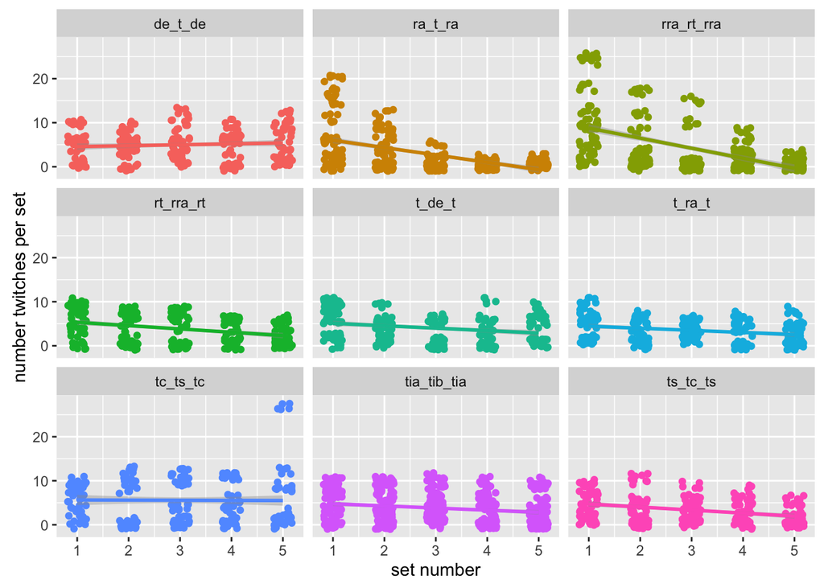

The code for this releveling is below, just in case you want to run it, otherwise it is supressed:

```r
attn_habit_3$trial_name_2 <- relevel(attn_habit_3$trial_name_2,"ra_t_ra") #MAKE RA REFERENCE
nlme_ra_ref<- lme(all_tw_call ~ call_num*trial_name_2, random = list(Bat_ID=~1 , trial_number= ~1), data= attn_habit_3)
summary(nlme_ra_ref)

attn_habit_3$trial_name_2 <- relevel(attn_habit_3$trial_name_2,"rra_rt_rra") #MAKE RRA REFERENCE
nlme_rra_ref<- lme(all_tw_call ~ call_num*trial_name_2, random = list(Bat_ID=~1 , trial_number= ~1), data= attn_habit_3)
summary(nlme_rra_ref)

attn_habit_3$trial_name_2 <- relevel(attn_habit_3$trial_name_2,"rt_rra_rt") #MAKE RT REFERENCE
nlme_rt_ref<- lme(all_tw_call ~ call_num*trial_name_2, random = list(Bat_ID=~1 , trial_number= ~1), data= attn_habit_3)
summary(nlme_rt_ref)

attn_habit_3$trial_name_2 <- relevel(attn_habit_3$trial_name_2,"t_de_t") #MAKE t_de REFERENCE
nlme_t_de_ref<- lme(all_tw_call ~ call_num*trial_name_2, random = list(Bat_ID=~1 , trial_number= ~1), data= attn_habit_3)
summary(nlme_t_de_ref)

attn_habit_3$trial_name_2 <- relevel(attn_habit_3$trial_name_2,"t_ra_t") #MAKE t_ra REFERENCE
nlme_t_ra_ref<- lme(all_tw_call ~ call_num*trial_name_2, random = list(Bat_ID=~1 , trial_number= ~1), data= attn_habit_3)
summary(nlme_t_ra_ref)

attn_habit_3$trial_name_2 <- relevel(attn_habit_3$trial_name_2,"tc_ts_tc") #MAKE TC REFERENCE
nlme_tc_ref<- lme(all_tw_call ~ call_num*trial_name_2, random = list(Bat_ID=~1 , trial_number= ~1), data= attn_habit_3)
summary(nlme_tc_ref)

attn_habit_3$trial_name_2 <- relevel(attn_habit_3$trial_name_2,"tia_tib_tia") #MAKE TIA REFERENCE
nlme_tia_ref<- lme(all_tw_call ~ call_num*trial_name_2, random = list(Bat_ID=~1 , trial_number= ~1), data= attn_habit_3)
summary(nlme_tia_ref)

attn_habit_3$trial_name_2 <- relevel(attn_habit_3$trial_name_2,"ts_tc_ts") #MAKE ts REFERENCE
nlme_ts_ref<- lme(all_tw_call ~ call_num*trial_name_2, random = list(Bat_ID=~1 , trial_number= ~1), data= attn_habit_3)
summary(nlme_ts_ref)
```

##### 9.

Again, what should my significance level be? This seems like a lot of comparisons. Is there some kind of bootstrapping for these tests?

# Discrimination

Call number can be grouped into sets. I want to know if there is a difference between the 5th and 6th sets, and between the 5th and 7th set. A significantly greater response to the 6th or 7th set from the 5th set is indicative of discrimination between the stimuli. In all cases the response was the total number of ear twitches. I analysed this by subsetting the data and running a lme on each treatment. Since I’m not comparing between treatments in this part I thought this would be acceptable.

To analyze these, I used linear mixed models with the following model:

```
   *total twitches ~ set number , random = bat*

  (I used trial_number in other models in this analysis, but it did not explain more of the variance in this case)
```

Data download and prep:

```
## [1] "numeric"
```

```
## [1] de_t_de     ra_t_ra     rra_rt_rra  rt_rra_rt   t_de_t      t_ra_t
## [7] tc_ts_tc    tia_tib_tia ts_tc_ts
## 11 Levels: de_t_de ra_t_ra rra_rt_rra rt_rra_rt rt_t_rt t_de_t ... ts_tc_ts
```

Below I am going to include all the tests just in case they are useful, but I really only have one question here:

##### 10.

Some of the subsets seem reasonably normally distributed, but others really don’t. Do you think it is acceptable to run some of the treatments with transformed data, and others without? Or is that a faux pas of some sort? Finally, some of them are pretty awfully 0 weighted, so it doesn’t seem as if any sort of transformation is going to make it normal.

# Thank you so so so much for your help

###################################################################################

### *D. ebracattus* v Tungara:

normality of data:

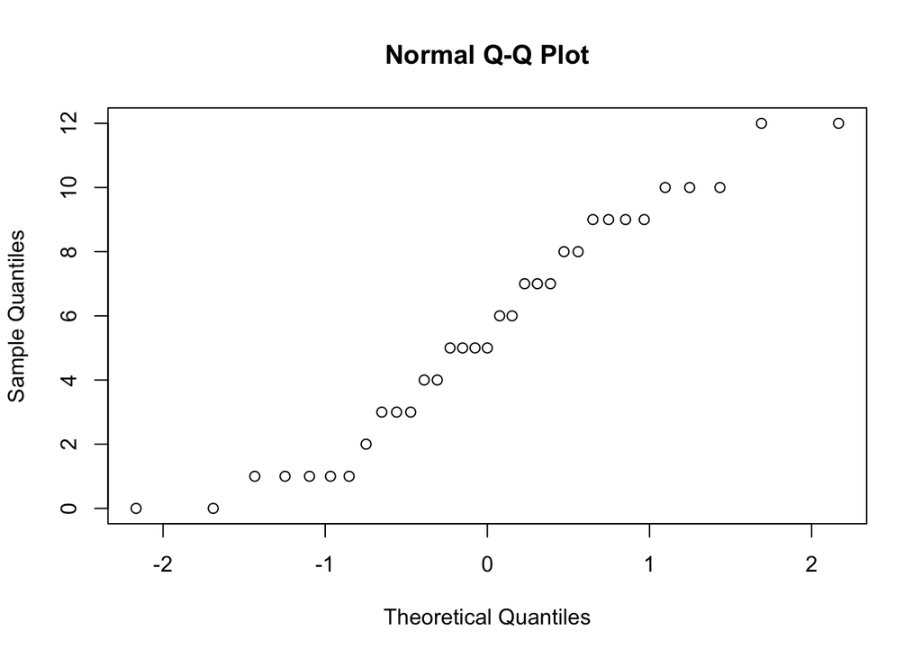

Results of linear mixed model: This models asks whether there is a significant difference between set 5 & 6, and 5 & 7.

```r
summary(de_desc)
```

```
## Linear mixed-effects model fit by REML
##  Data: subset_de1
##        AIC      BIC    logLik
##   174.4325 181.4385 -82.21626
##
## Random effects:
##  Formula: ~1 | Bat_ID
##         (Intercept) Residual
## StdDev:    2.553695  2.66855
##
## Fixed effects: all_tw_set ~ as.factor(set_num)
##                         Value Std.Error DF   t-value p-value
## (Intercept)          5.545455  1.113656 20  4.979505  0.0001
## as.factor(set_num)6  0.363636  1.137874 20  0.319575  0.7526
## as.factor(set_num)7 -0.363636  1.137874 20 -0.319575  0.7526
##  Correlation:
##                     (Intr) a.(_)6
## as.factor(set_num)6 -0.511
## as.factor(set_num)7 -0.511  0.500
##
## Standardized Within-Group Residuals:
##        Min         Q1        Med         Q3        Max
## -1.6366425 -0.6014397 -0.1182806  0.4817253  2.0660214
##
## Number of Observations: 33
## Number of Groups: 11
```

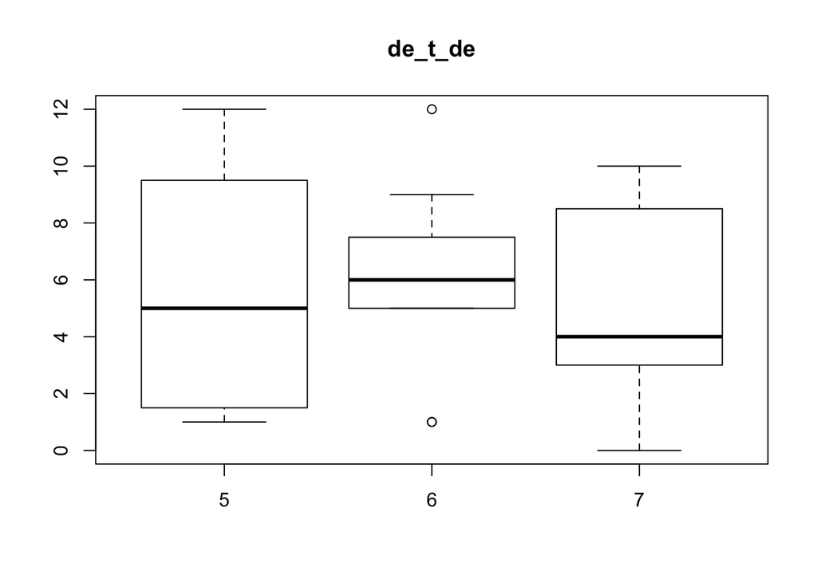

```r
de_t_de_desc <- boxplot(all_tw_set ~ (as.factor(set_num)), main = "de_t_de", data=subset_de1)
```

So, there is no evidence of discrimination between ebracattus and tungara. This may be because there was no habituation to D. ebracattus (actually there was slight sensitization)

### *Rhinella alata* v Tungara

normality of data:

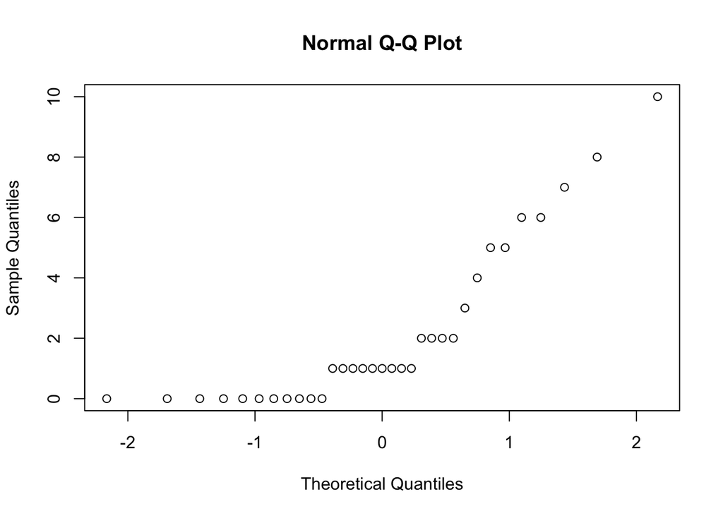

```r
qqnorm(subset_ra1$all_tw_set)
```

```r
summary(ra_desc)
```

```
## Linear mixed-effects model fit by REML
##  Data: subset_ra1
##        AIC      BIC    logLik
##   149.9829 156.9889 -69.99143
##
## Random effects:
##  Formula: ~1 | Bat_ID
##         (Intercept) Residual
## StdDev:    1.058873 1.998484
##
## Fixed effects: all_tw_set ~ as.factor(set_num)
##                        Value Std.Error DF  t-value p-value
## (Intercept)         0.636364 0.6819192 20 0.933195  0.3618
## as.factor(set_num)6 3.636364 0.8521565 20 4.267248  0.0004
## as.factor(set_num)7 0.909091 0.8521565 20 1.066812  0.2988
##  Correlation:
##                     (Intr) a.(_)6
## as.factor(set_num)6 -0.625
## as.factor(set_num)7 -0.625  0.500
##
## Standardized Within-Group Residuals:
##          Min           Q1          Med           Q3          Max
## -1.798315082 -0.433644446 -0.009517418  0.398572263  2.366702992
##
## Number of Observations: 33
## Number of Groups: 11
```

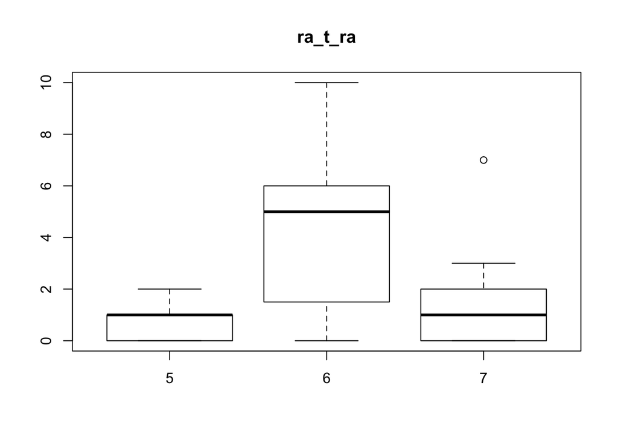

```r
#boxplot
ra_descrim_plot<- boxplot(all_tw_set ~ (as.factor(set_num)), main = "ra_t_ra", data=subset_ra1)
```

There is evidence for descrimination between rhinella alata and tungara frogs

### Reversed *R. alata* v tungara

Normality of data:

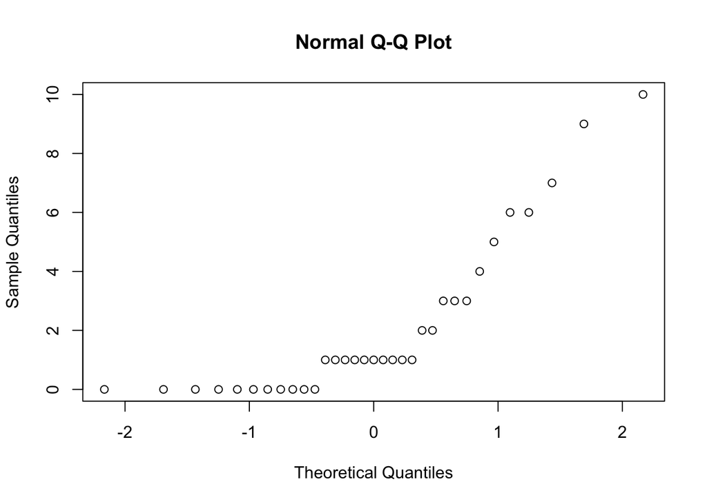

```r
qqnorm(subset_rra1$all_tw_set)
```

```r
summary(rra_desc)
```

```
## Linear mixed-effects model fit by REML
##  Data: subset_rra1
##        AIC      BIC    logLik
##   144.1352 151.1412 -67.06762
##
## Random effects:
##  Formula: ~1 | Bat_ID
##         (Intercept) Residual
## StdDev:     0.98165 1.805715
##
## Fixed effects: all_tw_set ~ as.factor(set_num)
##                        Value Std.Error DF  t-value p-value
## (Intercept)         0.636364 0.6196951 20 1.026898  0.3167
## as.factor(set_num)6 4.090909 0.7699594 20 5.313149  0.0000
## as.factor(set_num)7 0.363636 0.7699594 20 0.472280  0.6418
##  Correlation:
##                     (Intr) a.(_)6
## as.factor(set_num)6 -0.621
## as.factor(set_num)7 -0.621  0.500
##
## Standardized Within-Group Residuals:
##         Min          Q1         Med          Q3         Max
## -2.23939457 -0.37121532 -0.05520614  0.40643222  2.17079604
##
## Number of Observations: 33
## Number of Groups: 11
```

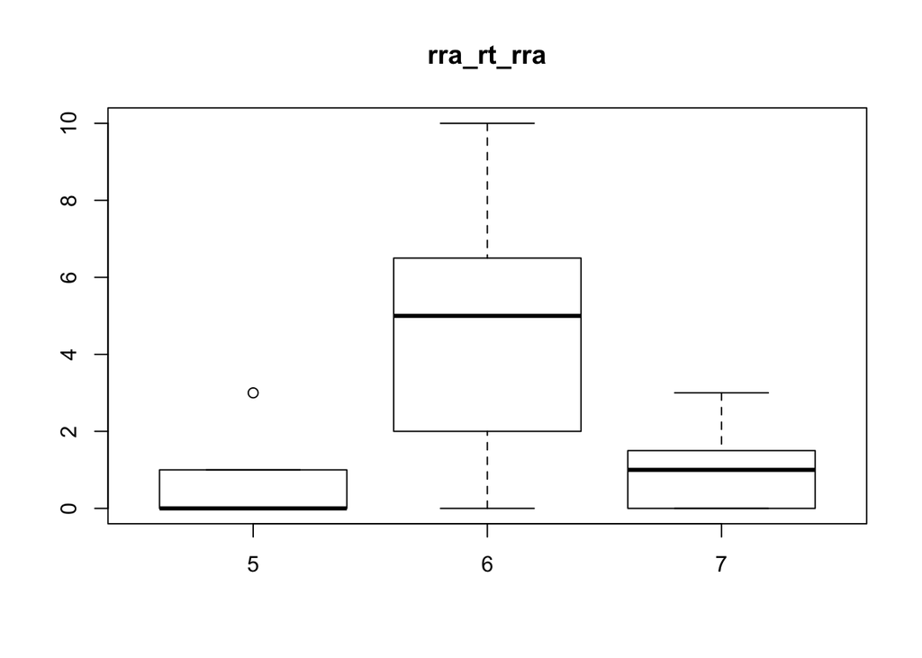

```r
#boxplot
boxplot(all_tw_set ~ (as.factor(set_num)), main = "rra_rt_rra", data=subset_rra1)
```

There is evidence for descrimination between 5 and 6, but not for dishabituation (5 and 7). There was very steep habituation to reversed rhinella alata, which might explain a part of this trend.

### reversed tungara v reversed *R. alata*

Normality of data:

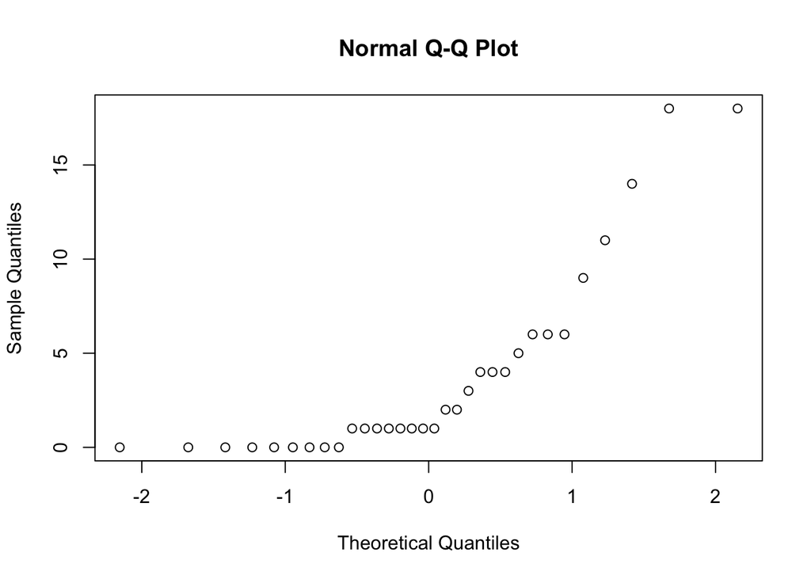

This linear mixed model may not be appropriate for this test given its right-skewed distribution

```r
summary(rt_desc)
```

```
## Linear mixed-effects model fit by REML
##  Data: subset_rt1
##        AIC      BIC    logLik
##   191.4383 198.2748 -90.71915
##
## Random effects:
##  Formula: ~1 | Bat_ID
##         (Intercept) Residual
## StdDev:    1.286115 4.729258
##
## Fixed effects: all_tw_set ~ as.factor(set_num)
##                        Value Std.Error DF   t-value p-value
## (Intercept)         2.114783  1.549213 19 1.3650692  0.1882
## as.factor(set_num)6 3.857888  2.029765 19 1.9006573  0.0726
## as.factor(set_num)7 0.618013  2.121642 19 0.2912898  0.7740
##  Correlation:
##                     (Intr) a.(_)6
## as.factor(set_num)6 -0.715
## as.factor(set_num)7 -0.685  0.520
##
## Standardized Within-Group Residuals:
##        Min         Q1        Med         Q3        Max
## -1.2652198 -0.5469727 -0.1676297  0.4453172  2.2623793
##
## Number of Observations: 32
## Number of Groups: 11
```

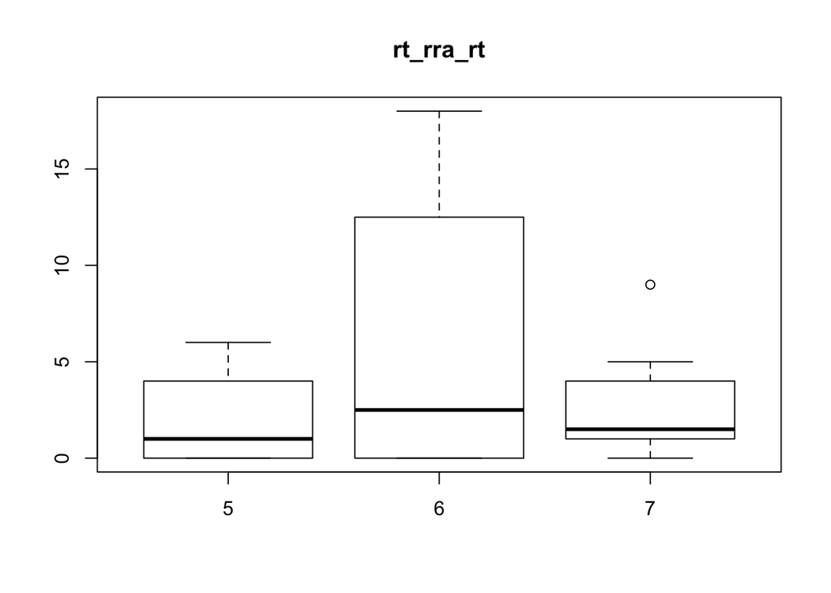

```r
#boxplot
boxplot(all_tw_set ~ (as.factor(set_num)), main = "rt_rra_rt", data=subset_rt1)
```

Is it okay to transform a subset of data and not all of it? If so, I can maybe log or sqrt some of these contrasts that are more skewed so that this test is appropriate.For example:

## Log +1 transformed reversed tungara v reversed rhinella alata

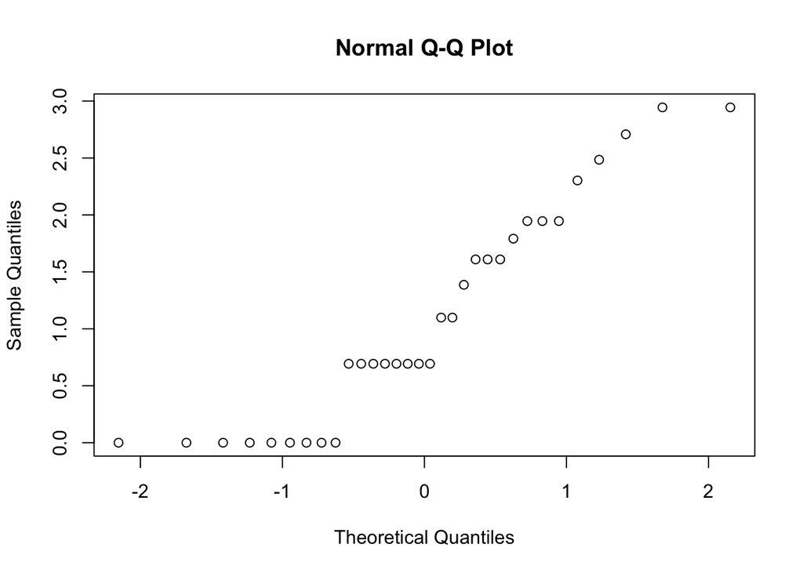

```
## Linear mixed-effects model fit by REML
##  Data: subset_rt1
##        AIC     BIC    logLik
##   97.52752 104.364 -43.76376
##
## Random effects:
##  Formula: ~1 | Bat_ID
##          (Intercept)  Residual
## StdDev: 3.296396e-05 0.9684232
##
## Fixed effects: (log(all_tw_set + 1)) ~ as.factor(set_num)
##                         Value Std.Error DF   t-value p-value
## (Intercept)         0.8679312 0.3062423 19 2.8341323  0.0106
## as.factor(set_num)6 0.4673586 0.4146540 19 1.1271048  0.2737
## as.factor(set_num)7 0.1588819 0.4330920 19 0.3668547  0.7178
##  Correlation:
##                     (Intr) a.(_)6
## as.factor(set_num)6 -0.739
## as.factor(set_num)7 -0.707  0.522
##
## Standardized Within-Group Residuals:
##        Min         Q1        Med         Q3        Max
## -1.3788288 -0.8962313 -0.1804831  0.7717356  1.6616178
##
## Number of Observations: 32
## Number of Groups: 11
```

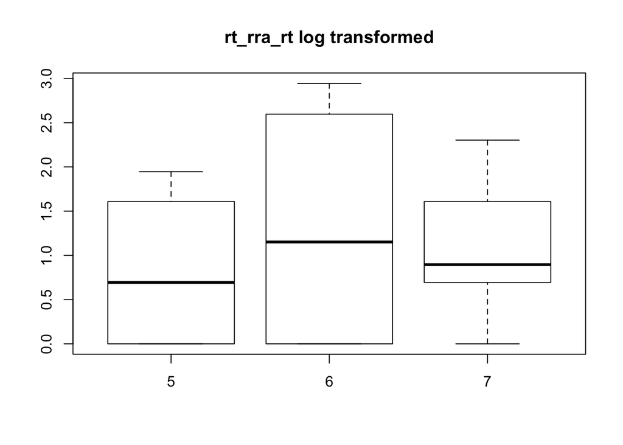

Regardless, in this case there is no evidence of descrimination between reversed tungara and reversed alata, due mainly to low overall values.

### Tungara v *D. ebracattus*

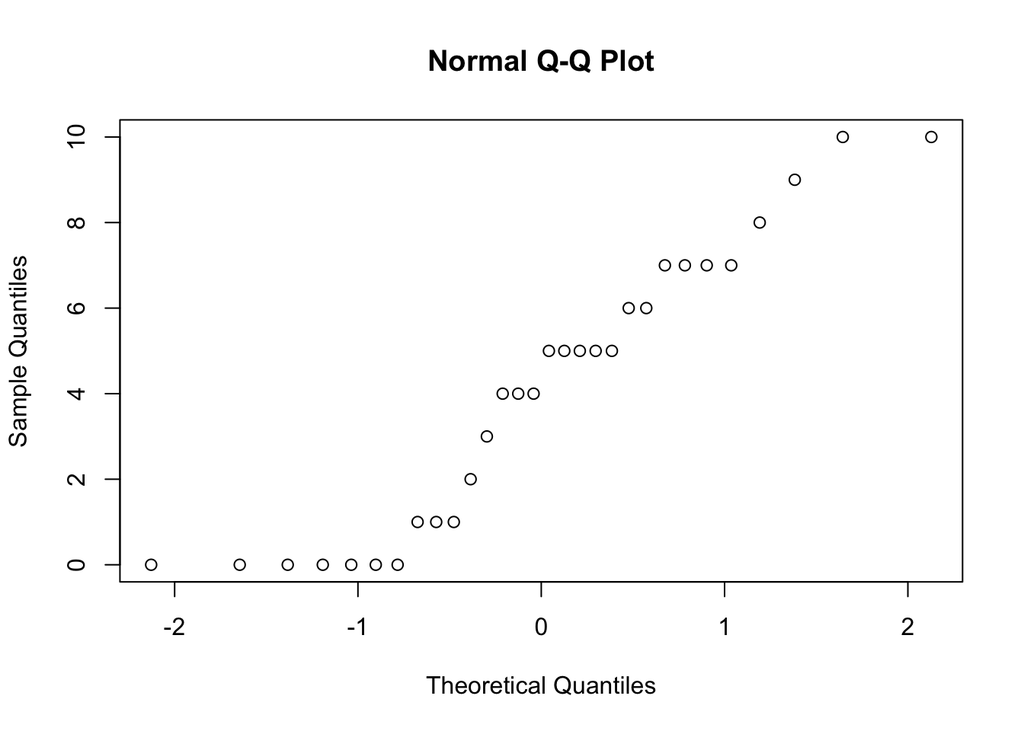

```
## Linear mixed-effects model fit by REML
##  Data: subset_t_de1
##        AIC      BIC    logLik
##   155.0511 161.5303 -72.52554
##
## Random effects:
##  Formula: ~1 | Bat_ID
##         (Intercept) Residual
## StdDev:    1.824723  2.70733
##
## Fixed effects: all_tw_set ~ as.factor(set_num)
##                     Value Std.Error DF   t-value p-value
## (Intercept)           4.1  1.032436 18  3.971189  0.0009
## as.factor(set_num)6   0.9  1.210755 18  0.743338  0.4669
## as.factor(set_num)7  -1.0  1.210755 18 -0.825931  0.4197
##  Correlation:
##                     (Intr) a.(_)6
## as.factor(set_num)6 -0.586
## as.factor(set_num)7 -0.586  0.500
##
## Standardized Within-Group Residuals:
##         Min          Q1         Med          Q3         Max
## -1.97466254 -0.60663265 -0.03679311  0.62723383  1.68207609
##
## Number of Observations: 30
## Number of Groups: 10
```

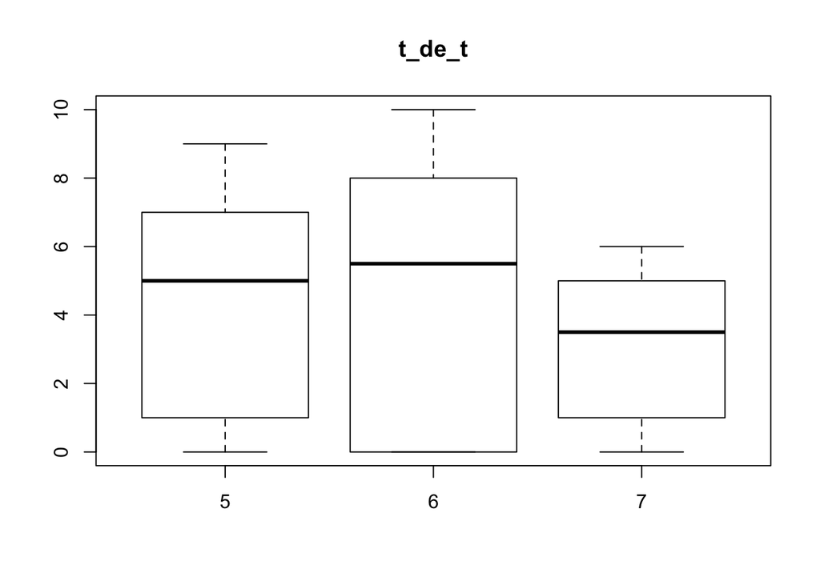

There is no evidence for descrimination between tungara and dendrobates Perhaps due to high overall responses

### Tungara v R. alata

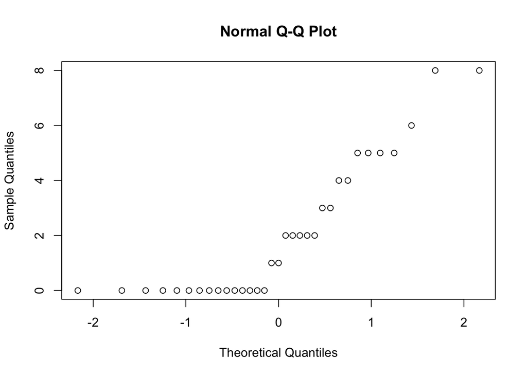

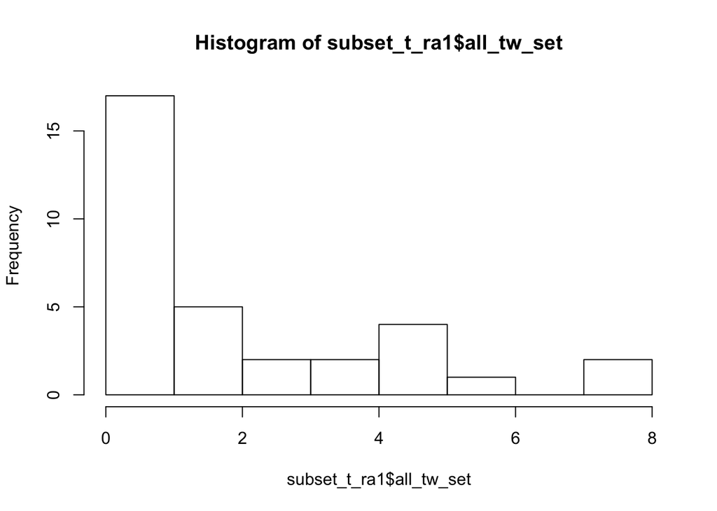

```
## Linear mixed-effects model fit by REML
##  Data: subset_t_ra1
##        AIC      BIC    logLik
##   144.7906 151.7965 -67.39528
##
## Random effects:
##  Formula: ~1 | Bat_ID
##         (Intercept) Residual
## StdDev:     2.03306 1.479148
##
## Fixed effects: all_tw_set ~ as.factor(set_num)
##                          Value Std.Error DF   t-value p-value
## (Intercept)          2.4545455 0.7580605 20  3.237928  0.0041
## as.factor(set_num)6 -1.0000000 0.6307108 20 -1.585513  0.1285
## as.factor(set_num)7 -0.1818182 0.6307108 20 -0.288275  0.7761
##  Correlation:
##                     (Intr) a.(_)6
## as.factor(set_num)6 -0.416
## as.factor(set_num)7 -0.416  0.500
##
## Standardized Within-Group Residuals:
##        Min         Q1        Med         Q3        Max
## -2.2679083 -0.5654259 -0.1823131  0.6166727  1.6655601
##
## Number of Observations: 33
## Number of Groups: 11
```

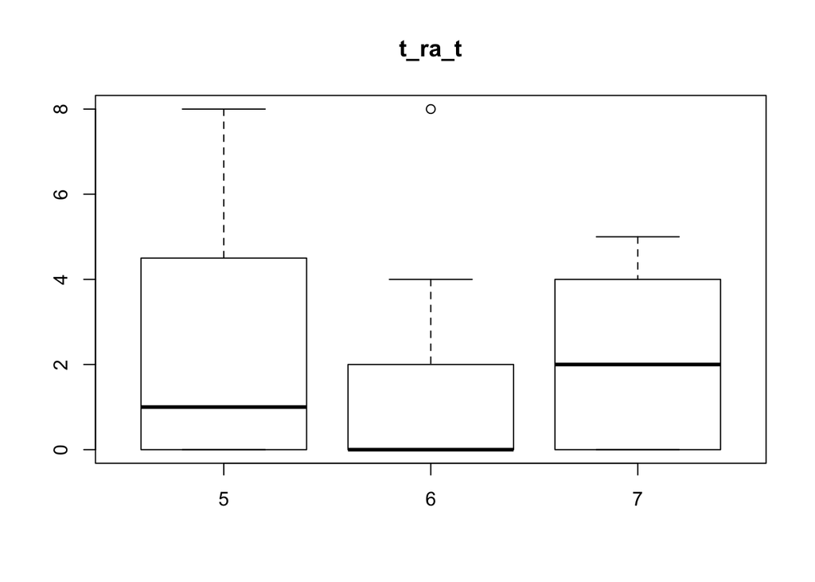

No discimination between treatments detected. If it is appropriate to transform these, then:

# Square-root transformed tungara v R. alata

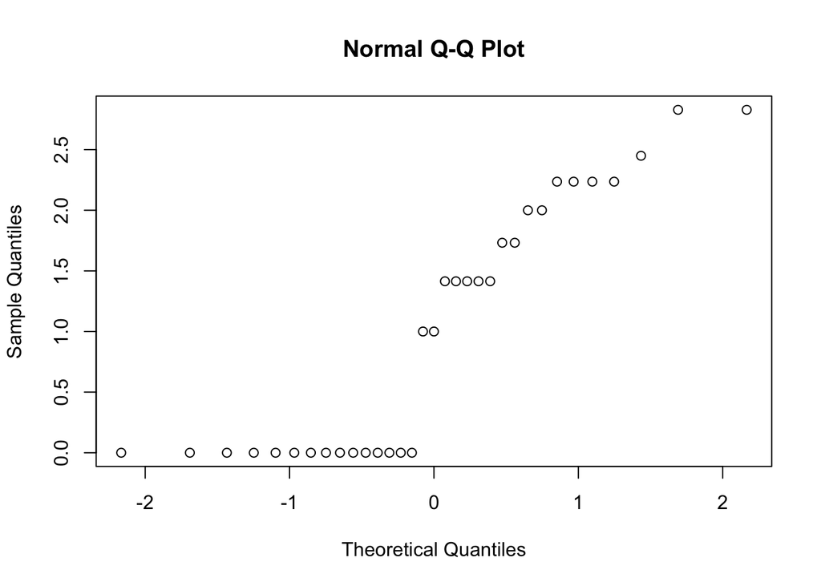

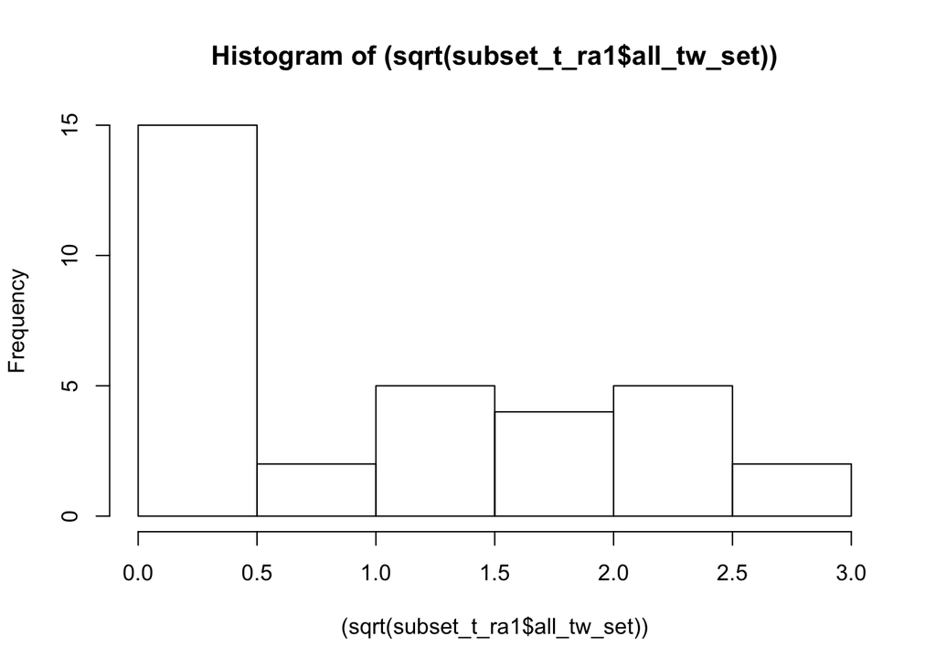

```
## Linear mixed-effects model fit by REML
##  Data: subset_t_ra1
##        AIC      BIC    logLik
##   93.66424 100.6702 -41.83212
##
## Random effects:
##  Formula: ~1 | Bat_ID
##         (Intercept)  Residual
## StdDev:   0.8056345 0.6490782
##
## Fixed effects: (sqrt(all_tw_set)) ~ as.factor(set_num)
##                          Value Std.Error DF   t-value p-value
## (Intercept)          1.1752908 0.3119367 20  3.767722  0.0012
## as.factor(set_num)6 -0.4792131 0.2767679 20 -1.731462  0.0988
## as.factor(set_num)7  0.0065940 0.2767679 20  0.023825  0.9812
##  Correlation:
##                     (Intr) a.(_)6
## as.factor(set_num)6 -0.444
## as.factor(set_num)7 -0.444  0.500
##
## Standardized Within-Group Residuals:
##          Min           Q1          Med           Q3          Max
## -2.410354727 -0.521630377  0.009933568  0.463016660  1.419395142
##
## Number of Observations: 33
## Number of Groups: 11
```

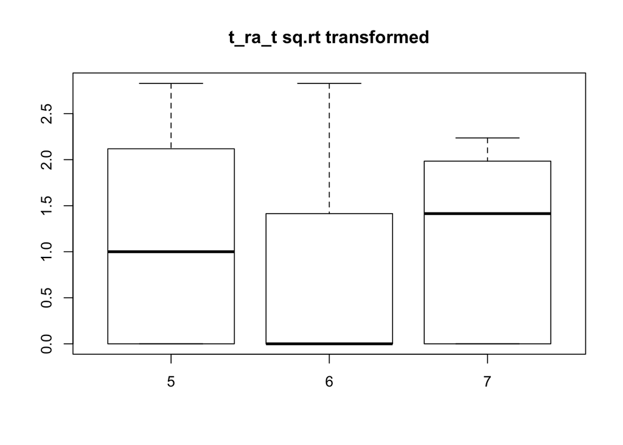

```
## Linear mixed-effects model fit by REML
##  Data: subset_t_ra1
##        AIC      BIC    logLik
##   93.66424 100.6702 -41.83212
##
## Random effects:
##  Formula: ~1 | Bat_ID
##         (Intercept)  Residual
## StdDev:   0.8056345 0.6490782
##
## Fixed effects: (sqrt(all_tw_set)) ~ as.factor(set_num)
##                         Value Std.Error DF  t-value p-value
## (Intercept)         0.6960777 0.3119367 20 2.231471  0.0373
## as.factor(set_num)5 0.4792131 0.2767679 20 1.731462  0.0988
## as.factor(set_num)7 0.4858071 0.2767679 20 1.755287  0.0945
##  Correlation:
##                     (Intr) a.(_)5
## as.factor(set_num)5 -0.444
## as.factor(set_num)7 -0.444  0.500
##
## Standardized Within-Group Residuals:
##          Min           Q1          Med           Q3          Max
## -2.410354727 -0.521630377  0.009933568  0.463016660  1.419395142
##
## Number of Observations: 33
## Number of Groups: 11
```

So, there is a marginally significant difference between 6 and 7 (p=0.0945), and 6 and 5 (p=0.0988). But not sure what my alpha level should be.

# Intraspecific Trials

## Complex tungara v simple tungara

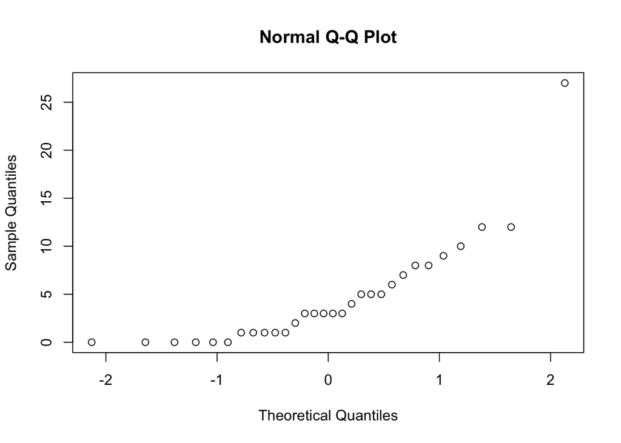

```r
qqnorm(subset_tc1$all_tw_set)
```

```r
#one total outlier (what should I do about that?)
tc_desc<- lme(all_tw_set ~ as.factor(set_num), random = ~1|Bat_ID, data = subset_tc1) # use as.factor so  sees these as factors
summary(tc_desc)
```

```
## Linear mixed-effects model fit by REML
##  Data: subset_tc1
##        AIC      BIC    logLik
##   184.4602 190.9394 -87.23011
##
## Random effects:
##  Formula: ~1 | Bat_ID
##         (Intercept) Residual
## StdDev:    3.093591 4.685679
##
## Fixed effects: all_tw_set ~ as.factor(set_num)
##                     Value Std.Error DF   t-value p-value
## (Intercept)           6.2  1.775553 18  3.491869  0.0026
## as.factor(set_num)6  -3.2  2.095499 18 -1.527082  0.1441
## as.factor(set_num)7  -1.4  2.095499 18 -0.668098  0.5125
##  Correlation:
##                     (Intr) a.(_)6
## as.factor(set_num)6 -0.59
## as.factor(set_num)7 -0.59   0.50
##
## Standardized Within-Group Residuals:
##         Min          Q1         Med          Q3         Max
## -1.19275683 -0.50627167 -0.06284046  0.25728650  3.67313320
##
## Number of Observations: 30
## Number of Groups: 10
```

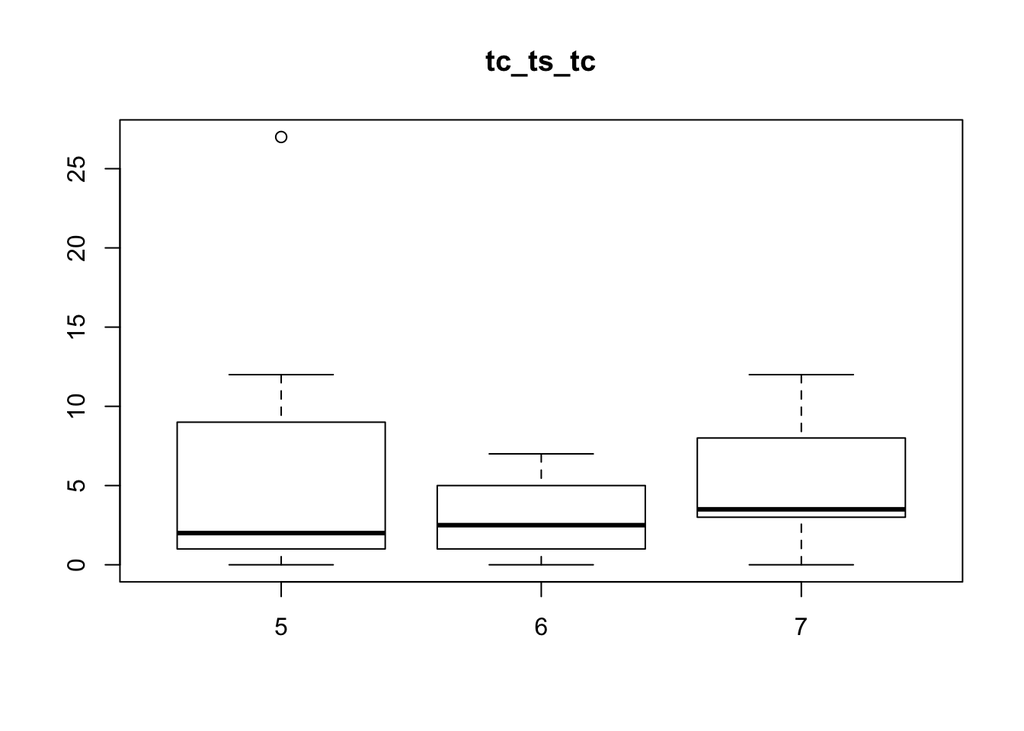

```r
# boxplot
tc_ts_tc_plot<- boxplot(all_tw_set ~ (as.factor(set_num)), main = "tc_ts_tc", data=subset_tc1)
```

There is no apparent discrimination between complex and simple calls in this test. However, there is an outlier that could easily be messing with this. I’m going to think about this a little.

If this is accurate, it is probable that discrimination is obscured by simple calls being less salient stimuli, so the interuption in habituation is masked by lower overall interest in the simple call. See the inverse treatment:

## Simple tungara against complex tungara call

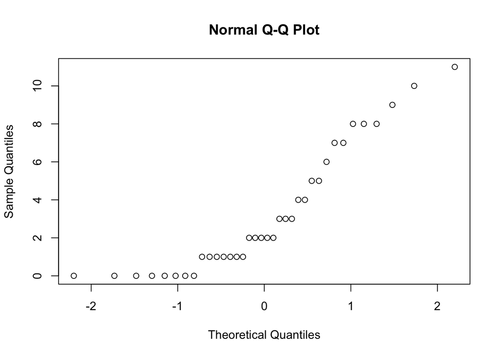

```r
qqnorm(subset_ts1$all_tw_set)
```

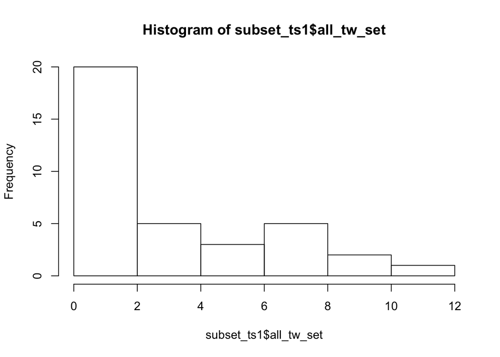

```r
hist(subset_ts1$all_tw_set)
```

```r
#looks oookay (pretty 0 weighted)
ts_desc<- lme(all_tw_set ~ as.factor(set_num), random = ~1|Bat_ID, data = subset_ts1) # use as.factor so  sees these as factors
summary(ts_desc)
```

```
## Linear mixed-effects model fit by REML
##  Data: subset_ts1
##        AIC      BIC    logLik
##   176.9793 184.4618 -83.48964
##
## Random effects:
##  Formula: ~1 | Bat_ID
##         (Intercept) Residual
## StdDev:    2.346559 2.135023
##
## Fixed effects: all_tw_set ~ as.factor(set_num)
##                         Value Std.Error DF  t-value p-value
## (Intercept)         2.1273036 0.9407362 23 2.261318  0.0335
## as.factor(set_num)6 2.9166667 0.8716196 23 3.346261  0.0028
## as.factor(set_num)7 0.9166667 0.8716196 23 1.051682  0.3039
##  Correlation:
##                     (Intr) a.(_)6
## as.factor(set_num)6 -0.463
## as.factor(set_num)7 -0.463  0.500
##
## Standardized Within-Group Residuals:
##        Min         Q1        Med         Q3        Max
## -1.6029205 -0.5277668 -0.1863132  0.4319883  2.1831427
##
## Number of Observations: 36
## Number of Groups: 11
```

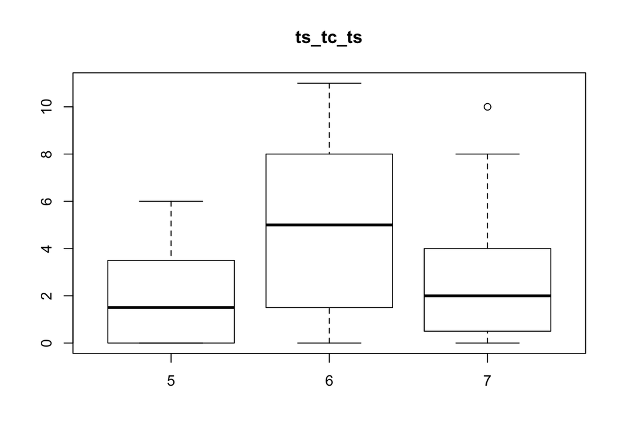

```r
# boxplot
ts_tc_ts_plot<- boxplot(all_tw_set ~ (as.factor(set_num)), main = "ts_tc_ts", data=subset_ts1)
```

There is support for discrimination between these two treatments, but no evidence of dishabituation. Note how discrimination is evidence when the less salient stimulus is the one that is being habituated.

## Tungara “A” v Tungara “B” (or the id of individuals trials)

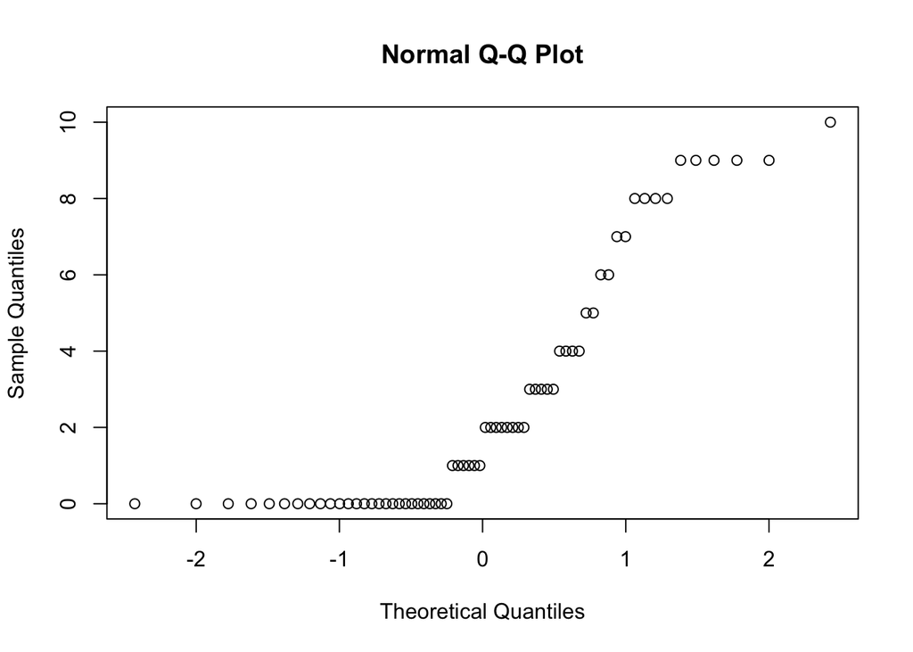

```r
qqnorm(subset_tia1$all_tw_set)
```

```r
# not justifiably normal (left/0 skewed)
tia_desc<- lme(all_tw_set ~ as.factor(set_num), random = ~1|Bat_ID, data = subset_tia1) # use as.factor so  sees these as factors
summary(tia_desc)
```

```
## Linear mixed-effects model fit by REML
##  Data: subset_tia1
##        AIC      BIC    logLik
##   309.6215 320.3371 -149.8107
##
## Random effects:
##  Formula: ~1 | Bat_ID
##         (Intercept) Residual
## StdDev:    2.554976 2.008131
##
## Fixed effects: all_tw_set ~ as.factor(set_num)
##                          Value Std.Error DF   t-value p-value
## (Intercept)          2.9090909 0.8813315 53  3.300791  0.0017
## as.factor(set_num)6  0.1363636 0.6054743 53  0.225218  0.8227
## as.factor(set_num)7 -0.8636364 0.6054743 53 -1.426380  0.1596
##  Correlation:
##                     (Intr) a.(_)6
## as.factor(set_num)6 -0.343
## as.factor(set_num)7 -0.343  0.500
##
## Standardized Within-Group Residuals:
##        Min         Q1        Med         Q3        Max
## -2.0329234 -0.5456740 -0.2321484  0.6839575  1.9508805
##
## Number of Observations: 66
## Number of Groups: 11
```

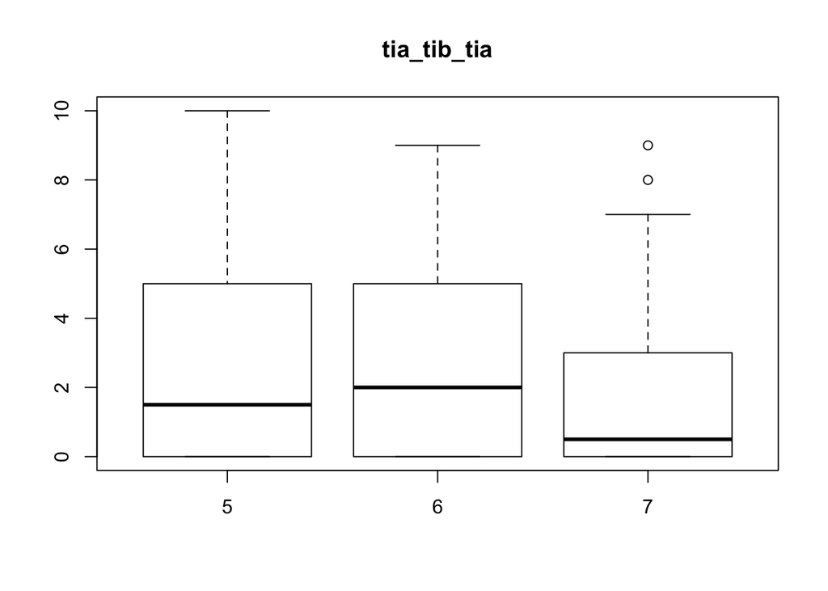

```r
# boxplot
tia_tib_tia_plot<- boxplot(all_tw_set ~ (as.factor(set_num)), main = "tia_tib_tia", data=subset_tia1)
```

There is no apparent discrimination between individual tungaras. But also the data are pretty non-normal, so:

## Square-root transformation of individual tungara trials

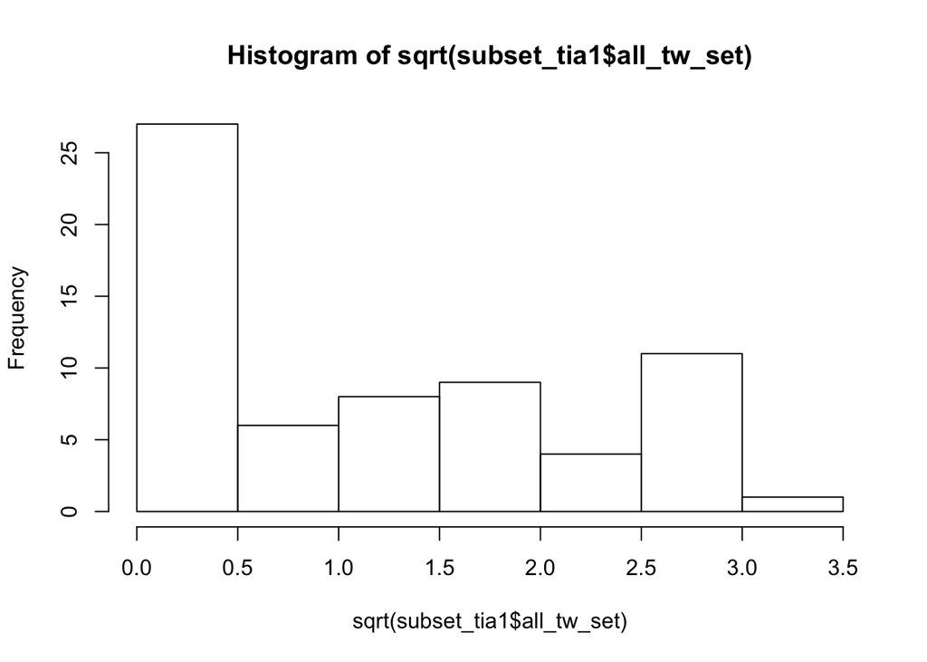

```r
hist(sqrt(subset_tia1$all_tw_set))
```

```r
# not justifiably normal (left/0 skewed)
tia_desc_sqrt_trans<- lme((sqrt(all_tw_set)) ~ as.factor(set_num), random = ~1|Bat_ID, data = subset_tia1) # use as.factor so  sees these as factors
summary(tia_desc_sqrt_trans)
```

```
## Linear mixed-effects model fit by REML
##  Data: subset_tia1
##       AIC      BIC    logLik
##   176.605 187.3207 -83.30251
##
## Random effects:
##  Formula: ~1 | Bat_ID
##         (Intercept)  Residual
## StdDev:    0.923083 0.6943125
##
## Fixed effects: (sqrt(all_tw_set)) ~ as.factor(set_num)
##                          Value Std.Error DF   t-value p-value
## (Intercept)          1.2336529 0.3152369 53  3.913416  0.0003
## as.factor(set_num)6  0.1365985 0.2093431 53  0.652510  0.5169
## as.factor(set_num)7 -0.2869860 0.2093431 53 -1.370888  0.1762
##  Correlation:
##                     (Intr) a.(_)6
## as.factor(set_num)6 -0.332
## as.factor(set_num)7 -0.332  0.500
##
## Standardized Within-Group Residuals:
##         Min          Q1         Med          Q3         Max
## -1.40223698 -0.75083908 -0.09560868  0.79538378  2.30893968
##
## Number of Observations: 66
## Number of Groups: 11
```

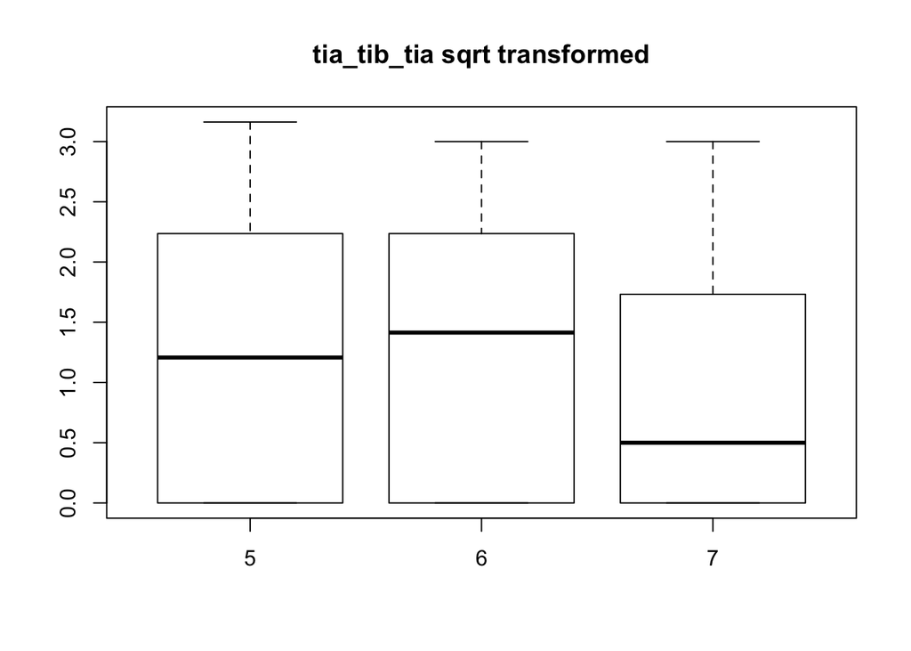

```r
# boxplot
tia_tib_tia_plot_sqrt<- boxplot((sqrt(all_tw_set)) ~ (as.factor(set_num)), main = "tia_tib_tia sqrt transformed", data=subset_tia1)
```

There is still no evidence of discrimination between individuals